# 2-2 확률 분포

# 2-2 확률 분포

#### 확률 변수

- 확률적인 과정의 결과를 수치적으로 표현하기 위한 임의의 수입니다. (일반적으로 대문자로 표기)

#### 기대값 E[X]

- 확률 변수의 평균적인 예상값으로 중심 경향성을 표현합니다.

> $E[X + Y] = E[X] + E[Y]$

> $E[aX] = aE[X]$

#### 분산 V(X)

- 데이터의 변동 정도를 측정하는 지표로 사용되며, 데이터가 중심(평균)으로 부터 흩어진 정도를 나타내는 지표입니다.

> $V(X)= E[(X - E[X])^2]=E[X^2] - E[X]^2$

> $V(X + Y)= V(X) + 2COV(X,Y) + V(Y)$

$V(X + Y) = E[(X + Y - E[X + Y])^2] = E[(X - E(X) + Y - E(Y))^2]$

$= E[X^2] - E(X)^2 + E[Y^2] - E(Y)^2 + 2E[(X - E[X])(Y - E[Y])] = V(X) + V(Y)+ 2COV(X,Y)$

> $V(aX)=a^2V(X)$

> $V(-aX)=a^2V(X)$

#### 공분산 COV(X, Y)

- 두 변수가 함께 변하는 정도를 나타냅니다.

> $COV(X, Y)=E[(X - E[X])(Y - E[Y])]=E[XY] - E[X][E[Y]$
- 두 변수가 독립이라면, $COV(X,Y) = 0$이 됩니다.

> **이 경우**, $V(X + Y) = V(X) + V(Y)$ 가 됩니다.

#### 표본평균의 모평균과 모분산

- 표본평균은 가설 검정과 신뢰구간등 두루 사용되는 통계량입니다.
- 표본평균도 확률 변수입니다. 표본평균의 모평균과 모분산을 대상 확률 변수의 모평균과 모분산에서 유도해 봅니다.

모평균이 $\mu$, 모분산이 $\sigma^2$인 모집단에서 n개의 표본을 추출했습니다.

> $X_1, X_2, X_3, ... X_n$

표본평균 $\bar{X}$는

$X_1, ... X_n$의 모평균이 $\mu$이므로 $E(X_1), ... E(X_n)$ 모두 $\mu$ 입니다.

> 따라서, $E(\bar{X}) = \frac{n\mu}{n} = \mu$

$V(\bar{X}) = V(\frac{X_1 + X_2 + ... + X_n}{n})$ 입니다.

**n개의 표본이 서로 독립이라면,**

$X_1, ... X_n$ 간의 공분산은 모두 $COV(X_1, X_2) = 0, ... COV(X_{n-1}, X_n) = 0$ 입니다.

> $V(\bar{X}) = V(\frac{X_1}{n}) + V(\frac{X_2}{n}) ... + V(\frac{X_n}{n})$

$X_1, ... X_n$은 모두 분산이 $\sigma^2$이므로 $V(X_1), ... V(X_n)$ 모두 $\sigma^2$ 이고, $V(aX) = a^2V(X)$이므로

> $V(\bar{X}) = \frac{\sigma^2}{n^2} + \frac{\sigma^2}{n^2}... + \frac{\sigma^2}{n^2} = \frac{\sigma^2}{n}$ 이 됩니다.

## 1. 이산형 확률 분포

- 이산형(Discrete) 확률 변수가 취하는 값에 대한 확률을 나타내는 분포

| 분포 | 확률 변수 | 매개변수 | 확률 질량 함수 | E(X) | V(X) |
| --- | --- | --- | --- | --- | --- |
| 베르누이(Bernoulii) 분포 | 베르누이 시행(0 또는 1)의 결과 | p: 1이 나올 확률 | $p(1)=p$ | $p$ | $$p\left(1-p\right)$$ |
| 이항(Binomial) 분포 | 연속된 n번의 베르누이 시행에서 n번 중 1이 나온 횟수 | p: 1이 나올 확률, n: 총 시행수 | $$p(x)={n \choose x}p^x(1-p)^{n-x}$$ | $np$ | $np(1-p)$ |
| 푸아송(Poisson) 분포 | 단위 시간 또는 공간에서 발생하는 사건수 | $$\lambda$$ : 단위 시간 또는 공간에서 발생하는 평균 사건수 | $$p(x)=\frac{e^{-\lambda}(\lambda)^x}{x!}$$ | $\lambda$ | $\lambda$ |

## 2. 연속형 확률 분포

- 연속형(Continuous) 확률 변수가 취하는 값에 대한 확률을 나타내는 분포

| 분포 | 확률 변수 | 매개변수 | 확률 밀도 함수 | E(X) | V(X) |
| --- | --- | --- | --- | --- | --- |
| 지수(Exponential) 분포 | 다음 사건이 발생하는 시간 | $\lambda$:단위 또는 시간 공간에서 발생하는 평균 사건 수 | $$\lambda e^{-\lambda x}$$ | $$\frac{1}{\lambda}$$ | $$\frac{1}{\lambda^2}$$ |
| 감마(Gamma) 분포 | 다음 $\alpha$개의 사건이 발생하는 평균 시간 | $\alpha$: 사건의 발생 횟수, $\beta$: 단위 시간 또는 공간에서 발생하는 평균 사건수 | $$\frac{\beta^\alpha x^{\alpha-1} e^{-\beta x}}{\Gamma(\alpha)}$$ | $$\frac{\alpha}{\beta}$$ | $$\frac{\alpha}{\beta^2}$$ |
| 정규(Normal) 분포 | 좌우 대칭의 종모양 분포 | $\mu$:평균, $\sigma^2$: 분산 | $$\frac{1}{\sigma\sqrt{2 \pi}}e^{-\frac{(x-\mu)^2}{2 \sigma^2}}$$ | $$\mu$$ | $$\sigma^2$$ |
| t 분포 | $$t=\frac{\bar{X} - \mu}{s/\sqrt{n}}$$ $$\bar{X}: \text{표본 평균}$$ $$\mu: \text{모평균}, s: \text{표본분산}$$ | $$\nu: \text{자유도}$$ | $$\frac{\Gamma\left(\frac{\nu + 1}{2}\right)}{\sqrt{\pi \nu} \Gamma\left(\frac{\nu}{2}\right)} \left(1 + \frac{t^2}{\nu}\right)^{-\frac{\nu + 1}{2}}$$ | 0, $$\nu > 1$$ | $$\frac{\nu}{\nu-2}, \nu > 2$$ |
| 카이 제곱(Chi-Square) | 표준 정규 분포를 따르는 k개의 독립인 확률 변수의 제곱의 합 분포 | k: 자유도 | $$\frac{1}{2^{k/2}\Gamma(k/2)} x^{k/2 - 1} e^{-x/2}$$ | k | 2k |
| F 분포 | 두 개의 카이 제곱 분포를 따르는 확률 변수의 비율 | d1: 분자의 자유도 d2: 분모의 자유도 | 별도 기재 | $$\frac{d_{2}}{d_{2}-2}$$ , $$d_2 > 2$$ | $$\frac{2\,d_{2}^{2}\,(d_{1}+d_{2}-2)}{d_{1}(d_{2}-2)^{2}(d_{2}-4)}$$ , $$d2 > 4$$ |

F 분포의 확률 밀도 함수:
$$\frac{\Gamma\left(\frac{d_1 +
d_2}{2}\right)}{\Gamma\left(\frac{d_1}{2}\right)\Gamma\left(\frac{d_2}{2}\right)}
\left(\frac{d_1}{d_2}\right)^{d_1/2} \frac{x^{d_1/2 - 1}}{\left(1 +
\frac{d_1}{d_2}x\right)^{\frac{d_1 + d_2}{2}}}$$

#### 자유도의 직관적 이해

- 주어진 확률 변수 중에서 임의로 변경이 가능한 값의 수입니다.

예] 표본 분산: $S = \sum_{i=1}^n\frac{(X_i - \bar{X})^2}{n - 1}$, ← 표본 분산의 분모(자유도)가 1 차감이 됩니다.

$\bar{X}=\frac{X_1 + X_2 + ... + X_n}{n}$ 표본 분산을 구할 때 표본평균을 사용합니다.

표본 분산을 구하는 과정에서 표본 평균이 고정이 됩니다. $X_1, ... X_n$ 변수중에서 하나의 값은 값이 고정이 됩니다.

n개의 확률 변수에서 한 개가 고정이 되므로 자유도가 n - 1이 됩니다.

**[Ex.1]**

n = 100, p = 0.3 인 이항분포에서 서로 독립인 표본 500개를 만들어 봅니다.

```r
library(ggplot2)
library(dplyr)

# 변수 설정
n <- 100 # 베르누이 시행의 수
p <- 0.3 # 결과가 1일 확률

# 데이터 생성
set.seed(123)
X <- rbinom(500, n, p)

# 표본의 평균과 모집단(이론적) 평균 출력
cat("표본의 평균:", mean(X), "모집단(이론적) 평균:", n * p, "\n")
```

```
표본의 평균: 29.644 모집단(이론적) 평균: 30
```

```r
# 표본의 분산과 모집단(이론적) 분산 출력
cat("표본의 분산:", var(X), "모집단(이론적) 분산:", n * p * (1 - p), "\n")
```

```
표본의 분산: 20.24175 모집단(이론적) 분산: 21
```

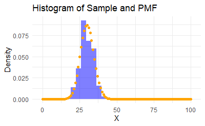

```r
# 히스토그램과 확률질량함수 그래프 그리기
hist_data <- data.frame(X)
pmf_data <- data.frame(x = 0:100, y = dbinom(0:100, n, p))

ggplot() +
  geom_histogram(aes(x = X, y = ..density..), data = hist_data, bins = 30, fill = 'blue', alpha = 0.5) +
  geom_point(aes(x = x, y = y), data = pmf_data, color = 'orange') +
  labs(x = 'X', y = 'Density') +
  ggtitle('Histogram of Sample and PMF') +
  theme_minimal()
```

**[Ex.2]**

1. X는 n = 100, p = 0.3인 이항분포를 따릅니다. $P(X=20)$을 구합니다.
2. X는 n = 100, p = 0.3 인 이항분포를 따릅니다. $P(X <= 20)$를 구합니다.
3. X는 n = 100, p = 0.3 인 이항분포를 따릅니다. $P(X <= A)=0.1$를 구합니다. 이 때, A를 구합니다.

```r
install.packages("stats")
# 이항 분포 확률질량함수 계산
n <- 100
p <- 0.3
k <- 20

# PMF 계산 및 출력
pmf_value <- dbinom(k, size = n, prob = p)
cat("1.", pmf_value, "\n")
```

```
1. 0.007575645
```

```r
# 변수 설정
n <- 100
p <- 0.3
k <- 20

# CDF 계산 및 출력
cdf_value <- pbinom(k, size = n, prob = p)
cat("2.", cdf_value, "\n")
```

```
2. 0.01646285
```

```r
# 변수 설정
n <- 100
p <- 0.3
q <- 0.1

# PPF 계산 및 출력
ppf_value <- qbinom(q, size = n, prob = p)
cat("3.", ppf_value, "\n")
```

```
3. 24
```

**[Ex.3]**

$\lambda$가 10인 포아송 분포에서 서로 독립인 표본 500개를 만들어 봅니다.

```r
# 변수 설정
lambda <- 10

# 데이터 생성
set.seed(123)
X <- rpois(500, lambda)

# 표본의 평균과 모집단(이론적) 평균 출력
cat("표본의 평균:", mean(X), "모집단(이론적) 평균:", lambda, "\n")
```

```
표본의 평균: 9.856 모집단(이론적) 평균: 10
```

```r
# 표본의 분산과 모집단(이론적) 분산 출력
cat("표본의 분산:", var(X), "모집단(이론적) 분산:", lambda, "\n")
```

```
표본의 분산: 9.374012 모집단(이론적) 분산: 10
```

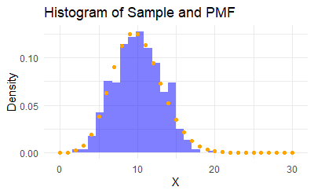

```r
# 히스토그램과 확률질량함수 그래프 그리기
hist_data <- data.frame(X)
pmf_data <- data.frame(x = 0:30, y = dpois(0:30, lambda))

ggplot() +
  geom_histogram(aes(x = X, y = ..density..), data = hist_data, bins = 30, fill = 'blue', alpha = 0.5) +
  geom_point(aes(x = x, y = y), data = pmf_data, color = 'orange') +
  labs(x = 'X', y = 'Density') +
  ggtitle('Histogram of Sample and PMF') +
  theme_minimal()
```

**[Ex.4]**

손님이 10분 동안에 평균 5명 온다고 할 때, 새로운 손님이 4분 이내에 올 확률을 지수 분포를 이용하여 구해봅니다.

손님이 오는 사건은 서로 독립입니다.

**[풀이]**

$\lambda=5$, 4분의 확률변수 X = 4분 / 10분,

$P(X \le 0.4; \lambda=5)$

```r
# 변수 설정
rate <- 5
x <- 0.4

# CDF 계산 및 출력
cdf_value <- pexp(x, rate = rate)
cat("CDF at x =", x, ":", cdf_value, "\n")
```

```
CDF at x = 0.4 : 0.8646647
```

## 3. 주요 분포의 특징

### 정규분포

**표준정규분포**: 평균이 0, 분산이 1인 정규 분포

**중심극한정리**: 표본평균의 분포는 모집단의 분포와 상관 없이 표본의 크기가 커질 수록 정규 분포에 가까워진다.

**[Ex.5]**

$\lambda$ 가 5인 포아송 분포에서 확률 변수를 n개씩 1000번 뽑아 각 표집의 표본평균을 구합니다.

(pvalue는 0과 1사이의 수이며 높을 수록 정규분포일 확률이 높음을 뜻합니다.)

[figure not shown]

```r
library(nortest)
library(gridExtra)

# 시드 설정
set.seed(123)
# 변수 설정
sample_sizes <- c(3, 10, 30, 100)
lambda <- 5

# 서브플롯을 그리기 위한 리스트 초기화
plots <- list()

# 각 샘플 크기에 대해 샘플 평균을 계산하고 히스토그램을 그리기
for (i in sample_sizes) {
  sam_mean <- replicate(1000, mean(rpois(i, lambda)))

  # 히스토그램 생성
  p <- ggplot(data.frame(sam_mean), aes(x = sam_mean)) +
    geom_histogram(aes(y = ..density..), bins = 30, fill = 'blue', alpha = 0.5) +
    labs(title = paste('Sample size:', i), x = 'Sample Mean', y = 'Density') +
    theme_minimal()

  # K-S 테스트 및 p-value 계산
  ks_test <- lillie.test(sam_mean)
  pvalue <- ks_test$p.value

  # 제목에 p-value 추가
  p <- p + ggtitle(paste('Sample size:', i, ', p-value:', format(pvalue, digits = 3)))

  # 리스트에 플롯 추가
  plots[[length(plots) + 1]] <- p
}

# 서브플롯을 2x2 형태로 그리기
grid.arrange(grobs = plots, ncol = 2)
```

## 카이제곱분포

$Z_1, ... Z_k$이 서로 독립이고 표준정규분포인 확률 함수 일 때,

$Q=\sum_{i=1}^{k}Z_i^2$

$Q \sim \chi^2_k$

#### 감마분포와의 관계

$\chi^2_k = \Gamma(\frac{k}{2}, \frac{1}{2})$

### t 분포

- t분포는 표준정규분포($Z$)와 $\chi^2_{n-1}$과의 아래와 결합으로 구성된 분포입니다. (n은 표본수)
- 태생적으로, t분포는 모집단이 정규분포를 따른다는 가정을 하고 있습니다.

> $t=\frac{\bar{X} - \mu}{\frac{s}{\sqrt{n}}}$, s는 표본표준편차. $s=\frac{1}{n-1}\sum_{i=1}^{n}\left(x_i - \bar{x} \right)^2$

> $t_{n-1} = \frac{Z}{\sqrt{\frac{\chi^2_{n-1}}{n-1}}}$

> $t_{\nu} = \frac{Z}{\sqrt{\frac{\chi^2_{\nu}}{\nu}}}, \nu=n-1$

**유도 과정**

$s^2=\frac{1}{n-1}\sum_{i=1}^{n}\left(X_i - \bar{X}\right)^2$

$(n-1)s^2=\sum_{i=1}^{n}\left(X_i -\mu + \mu - \bar{X}\right)^2$

$(n-1)s^2=\sum_{i=1}^{n}\left(\left(X_i -\mu\right)^2 + 2 \left(X_i -\mu \right) \left(\mu - \bar{X}\right) + \left(\mu - \bar{X}\right)^2\right)$

> $\sum_{i=1}^{n}2 \left(X_i -\mu \right) \left(\mu - \bar{X}\right) = \sum_{i=1}^{n}2 \left(X_i \mu - X_i \bar{X} - \mu^2 + \mu\bar{X}\right)$

> $= 2n \left(\bar{X}\mu - \bar{X}^2 - \mu^2 + \mu\bar{X}\right)$

> $= -2n\left(\bar{X} - \mu \right)^2$

$(n-1)s^2=\sum_{i=1}^{n}\left(X_i -\mu\right)^2 - 2n\left(\bar{X} - \mu \right)^2 + n \left(\mu - \bar{X}\right)^2$

$(n-1)\frac{s^2}{\sigma^2}=\sum_{i=1}^{n}\left(\frac{X_i -\mu}{\sigma}\right)^2 - n\left(\frac{\bar{X} - \mu}{\sigma}\right)^2=\sum_{i=1}^{n}\left(\frac{X_i -\mu}{\sigma}\right)^2 - \left(\frac{\bar{X} - \mu}{\frac{\sigma}{\sqrt{n}}}\right)^2$

> $\sum_{i=1}^{n}\left(\frac{X_i -\mu}{\sigma}\right)^2 \sim \chi^2_n, \left(\frac{\bar{X} - \mu}{\frac{\sigma}{\sqrt{n}}}\right)^2 \sim \chi^2_1$

> $chi^2_{n-1} = chi^2_n - chi^2_1$

따라서, $(n-1)\frac{s^2}{\sigma^2} \sim chi^2_{n-1}$

$t=\frac{\bar{X} - \mu}{\frac{s}{\sqrt{n}}}=\frac{\frac{\bar{X} - \mu}{\sigma}}{\frac{\frac{s}{\sigma}}{\sqrt{n}}}$

$=\frac{\frac{\bar{X} - \mu}{\frac{\sigma}{\sqrt{n}}}}{\frac{s}{\sigma}}$

$=\frac{Z}{\sqrt{\frac{(n-1)\frac{s^2}{\sigma^2}}{n-1}}} \sim \frac{Z}{\sqrt{\frac{\chi^2_{n-1}}{n-1}}}$

### F 분포

$S_1 \sim \chi^2_{d_1}$

$S_2 \sim \chi^2_{d_2}$

## 4. 신뢰 구간

- 신뢰 구간: 모집단의 모수에 대한 추정값이 존재할 것으로 예상되는 범위 나타냅니다.

> 표본에서 얻은 정보를 이용하여 모집단의 모수에 대한 가능한 값의 범위를 제시합니다.
- 신뢰 수준: 모집단의 모수가 신뢰 구간 내에 있을 확률입니다.

> 신뢰 구간을 95% 정한다면, 모수가 신뢰 구간에 있을 확률이 95%라는 것입니다.
- 신뢰 구간의 형태

> 점 추정치(Point Estimate) ± 주변 오차 범위(Margin of Error)
- 표본평균을 통한 신뢰 구간의 추청

> $P(-c \le 통계량 \le c) = \text{신뢰 수준}$

> $P(통계량 < -c) = \frac{\alpha}{2}$, $\alpha(\text{유의 수준}) = 1 - \text{신뢰 수준}$

> $-c = F^{-1}(\alpha/2)$, $F^{-1}$는 통계량의 분포의 누적확률함수의 역함수(Percentile Point Function)

> $c = -F^{-1}(\alpha/2)$
1. 모분산을 알고 있을 경우

> 정규분포를 사용합니다.

> $Z(\text{통계량}) = \frac{\bar{X} - \mu}{\sigma/\sqrt{n}}$

> $c = -Z_{\alpha/2}$, $-Z_{\alpha/2}$는 정규분포에서의 $F^{-1}(\alpha/2)$ 입니다.

> $-Z_{\alpha/2} \le \frac{\bar{X} - \mu}{\sigma/\sqrt{n}} \le Z_{\alpha/2}$

> $\bar{X} -Z_{\alpha/2}\frac{\sigma}{\sqrt{n}} \le \mu \le \bar{X} + Z_{\alpha/2}\frac{\sigma}{\sqrt{n}}$
2. 모분산을 모를 경우

> t-분포를 사용합니다.

> $t(\text{통계량}) = \frac{\bar{X} - \mu}{S/\sqrt{n}}$

> $c = -t_{\alpha/2,\nu=n-1}$, $-t_{\alpha/2,\nu=n-1}$는 t분포에서의 $F^{-1}(\alpha/2)$ 입니다.

> $-t_{\alpha/2,\nu=n-1} \le \frac{\bar{X} - \mu}{S/\sqrt{n}} \le t_{\alpha/2,\nu=n-1}$

> $\bar{X} -t_{\alpha/2,\nu=n-1}\frac{S}{\sqrt{n}} \le \mu \le \bar{X} + t_{\alpha/2,\nu=n-1}\frac{S}{\sqrt{n}}$

**[Ex.6]**

모분산이 4인 모집단에서 100개의 표본을 뽑았습니다. 이 때, 표본 평균이 124 입니다.

표본수 100개는, 표본평균의 분포가 정규분포를 따르기에 충분한 수라고 가정합니다.

이 때, 모평균의 신뢰구간을 구하세요.(신뢰수준이 95%)

**[풀이]**

$\alpha = 1 - 0.95 = 0.05$

$124 - Z_{0.025}\frac{2}{10} \le \mu \le 124 + Z_{0.025}\frac{2}{10}$

```r
# 변수 설정
sigma2 <- 4
n_sample <- 100
x_bar <- 124

# 표준 오차 계산
x_bar_std <- sqrt(sigma2 / n_sample)

# 임계값 계산
c <- -qnorm(0.025)

# 신뢰구간 계산
lower_bound <- x_bar - x_bar_std * c
upper_bound <- x_bar + x_bar_std * c

# 결과 출력
cat("신뢰구간: (", lower_bound, ",", upper_bound, ")\n")
```

[output not shown]

**[Ex.7]**

모집단은 정규분포를 따르고 25개 표본을 뽑았습니다. 이 때, 표본 평균이 104이고, 표본 분산이 9입니다.

모평균의 신뢰구간을 구하세요.(신뢰수준이 95%)

**[풀이]**

$104 -t_{0.025,\nu=24}\frac{3}{5} \le \mu \le 104 + t_{0.025,\nu=24}\frac{3}{5}$

```r
# 변수 설정
s2 <- 9
n_sample <- 25
x_bar <- 104

# 표준 오차 계산
s_div_sq <- sqrt(s2 / n_sample)

# 임계값 계산
c <- -qt(0.025, df = n_sample - 1)

# 신뢰구간 계산
lower_bound <- x_bar - s_div_sq * c
upper_bound <- x_bar + s_div_sq * c

# 결과 출력
cat("신뢰구간: (", lower_bound, ",", upper_bound, ")\n")
```

[output not shown]